# Homework 4

2023-02-01

# Question 1

Let $\psi = g(\theta)$, where g is a montone function of $\theta$, and h be the inverse of g so that $\theta = h(\psi)$. If $p_\theta (\theta)$ is the probability density of $\theta$, then the probability density of $\psi$ induced by $p_\theta$ is given by
$$p_\psi (\psi) = p_\theta (h(\psi)) \times
|\frac{dh}{d\psi}|$$

## Part A

Let $\theta$ ~ beta(a,b) and let $\psi$ = log[$\theta$ /(1-$\theta$)]. Obtain the form of $p_\psi$ and plot is for the case that $a=b=1$.

Hint: Show that
$$p_\psi(\psi) =
\frac{1}{B(a,b)}\frac{e^{a\psi}}{(e^\psi + 1)^{a+b}} =
\frac{e^{a\psi}}{(e^\psi + 1)^{2}}$$
when $a=b=1$

First, find $h(\psi)$.

$$\psi = log[\theta/(1-\theta)]$$
$$e^\psi = \theta/(1-\theta)$$
$$(1-\theta)e^\psi = \theta$$
$$e^\psi-\theta e^\psi = \theta$$
$$e^\psi= \theta + \theta e^\psi$$
$$e^\psi= \theta(1+ e^\psi)$$
$$\frac{e^\psi}{1+ e^\psi}= \theta$$
$$h(\psi) = \frac{e^\psi}{1+ e^\psi}$$
Next, find $\frac{dh}{d\psi}$

$$\frac{dh}{d\psi} =
\frac{(1+e^\psi)e^\psi - e^\psi e^\psi}{(1+e^\psi)^2}$$
$$\frac{dh}{d\psi} =
\frac{e^\psi}{(1+e^\psi)^2}$$
This is a positive value, so
$$\left|\frac{dh}{d\psi}\right| = \frac{dh}{d\psi}
= \frac{e^\psi}{(1+e^\psi)^2}$$

Now, find $p_\theta(\psi)$, given $p_\theta(\theta) = \frac{1}{B(a,b)}\theta^{a-1}(1-\theta)^{b-1}I_{[0,1]}(\theta)$.

$$p_\theta(h(\psi)) =
\frac{1}{B(a,b)}\left(\frac{e^\psi}{1+
e^\psi}\right)^{a-1}\left(1-\frac{e^\psi}{1+
e^\psi}\right)^{b-1}I_{[0,1]}\left(\frac{e^\psi}{1+
e^\psi}\right)$$

$$p_\theta(h(\psi)) =
\frac{1}{B(a,b)}\left(\frac{e^\psi}{1+
e^\psi}\right)^{a-1}\left(\frac{1}{1+ e^\psi}\right)^{b-1}$$

$$p_\theta(h(\psi)) =
\frac{1}{B(a,b)}\frac{e^{\psi(a-1)}}{(1+ e^\psi)^{a-1}}\frac{1}{(1+
e^\psi)^{b-1}}$$

$$p_\theta(h(\psi)) =
\frac{1}{B(a,b)}\frac{e^{\psi(a-1)}}{(1+ e^\psi)^{a+b-2}}$$

Finally, find $p_\psi(\psi)$.

$$p_\psi(\psi) = p_\theta(h(\psi)) \times
\left|\frac{dh}{d\psi}\right|$$

$$p_\psi(\psi)
= \frac{1}{B(a,b)}\frac{e^{\psi(a-1)}}{(1+ e^\psi)^{a+b-2}} \times
\frac{e^\psi}{(1+e^\psi)^2}$$

$$p_\psi(\psi)
= \frac{1}{B(a,b)}\frac{e^{a\psi}}{(1+ e^{\psi})^{a+b}}$$

For $a=b=1$,

$$p_\psi(\psi) = \frac{e^{\psi}}{(1+
e^{\psi})^{2}}$$

Finally, plot this for $a=b=1$.

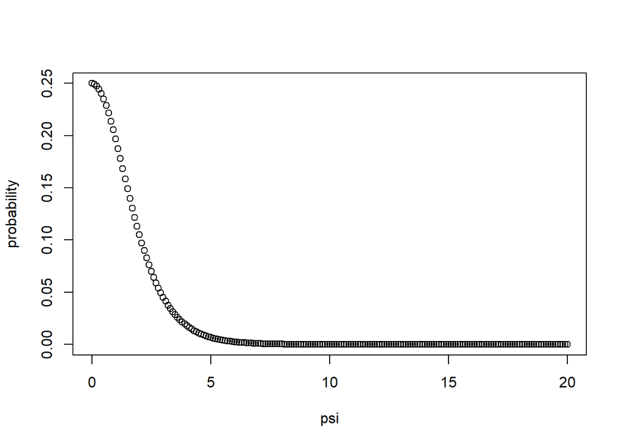

```r
psi <- seq(from = 0, to = 20, by = 0.1)
probability <- (exp(psi))/(1+exp(psi))^2

plot(psi, probability)
```

## Part B

Let $\theta$ ~ gamma(a=shape,b=rate) and let $\psi$ = log($\theta$). Obtain the form of $p_\psi$ and plot is for the case that $a=b=1$.

Hint: Show that
$$p_\psi(\psi) =
\frac{b^a}{\Gamma(a)}e^{a\psi -be^\psi} = e^{\psi-e^\psi}$$
when $a=b=1$

First, find $h(\psi)$.

$$\psi = log(\theta)$$
$$e^\psi = \theta$$
$$h(\psi) = e^\psi$$

Then, find $dh/d\psi$.
$$\frac{dh}{d\psi} = e^\psi$$
This is a positive function, so

$$\left|\frac{dh}{d\psi}\right| =
\frac{dh}{d\psi} = e^\psi$$

Next, find $p_\theta(\psi)$, given $p_\theta(\theta) = \frac{b^a}{\Gamma(a)}\theta^{a-1}e^{-b\theta}$.

$$p_\theta(h(\psi)) =
\frac{b^a}{\Gamma(a)}(e^\psi)^{a-1}e^{-be^\psi}$$

Finally, find $p_\psi(\psi)$.

$$p_\psi(\psi) = p_\theta(h(\psi)) \times
\left|\frac{dh}{d\psi}\right|$$

$$p_\psi(\psi) =
\frac{b^a}{\Gamma(a)}(e^\psi)^{a-1}e^{-be^\psi} \times
e^\psi$$

$$p_\psi(\psi) =
\frac{b^a}{\Gamma(a)}e^{a\psi-be^\psi}$$

If $a=b=1$, then
$$p_\psi(\psi) = e^{\psi-e^\psi}$$
Finally, plot this for $a=b=1$.

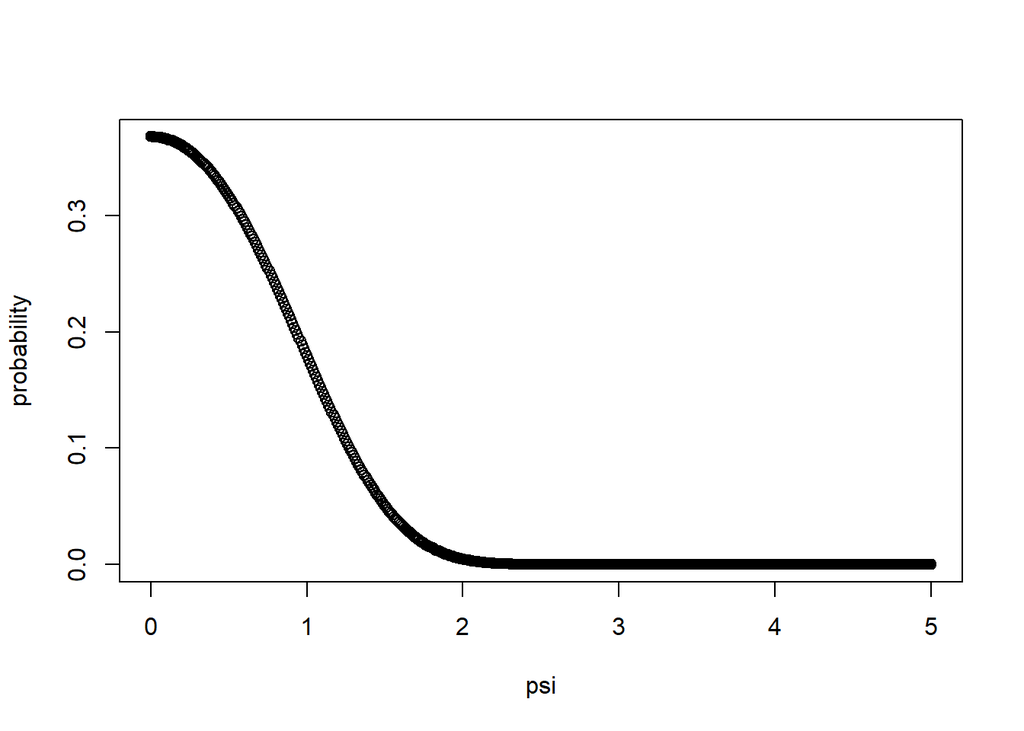

```r
psi <- seq(from = 0, to = 5, by = 0.01)
probability <- exp(psi-exp(psi))

plot(psi, probability)
```